# Inv.T-Rejection-Sampling

#### **Inv.Transform-and-Rejection-Sampling**

This repository contains the implementation of the **Inverse transform** sampling method for $X~\sim U(a, b)$ **uniformly distributed** continuous random variables:

*`PDF`* $\rightarrow$ $f(x)$ = $\frac{1}{b-a}$

if

$$F(x) = \int_{-\infty}^{x} f(x) dx = \int_{a}^{x} \frac{1}{b-a} dx = {\frac{x}{b-a}} \Big|_{a}^{x} = \frac{x-a}{b-a}$$

$\therefore$ The Inverse Transform *`CDF`* $\rightarrow F(X)$ *pseudo-random number samplings* $X_i \in [a, b]$ would be:

$$U = F^{-1}(X) = x(b-a) + a$$

$\&$ **Acceptance-Rejection** sampling method of given $f_{1,2}(x)$ over validation functions $t_{1,2,3}(x)$:

The methods are implemented with `scipy.optimize.fmin`, `numpy.random.random` $\&/or$ `numpy.random.uniform`.

$f(x)=30(x^2-2x^3+x^4)$

#### Maximization of $f(x)$ over $t(x)$ validation function.

1. Maximization of $f_1(x)$ over $t_1(x)$  
   $t_1(x)=a \sin(\Pi x)$ $\forall$ $x_i\in[0,1]$  
   $a$ = constant

```python
import numpy as np
import pandas as pd
import matplotlib.pyplot as plt
from scipy import optimize
%matplotlib inline

import warnings
warnings.filterwarnings("ignore")
```

#### 1. MarcoSC08

```
Functions, maximum point: [1.875]
```

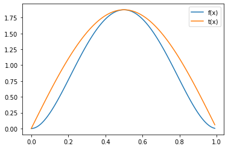

```python
f = lambda x: 30 * (x**2-2*x**3+x**4)
max_f = f(optimize.fmin(lambda x: -f(x), 0, disp=False))
t = lambda x: max_f * np.sin(np.pi*x)

x = np.arange(0,1,0.01)
print('Functions, maximum point:', max_f)

plt.plot(x,f(x),label='f(x)')
plt.plot(x,t(x),label='t(x)')
plt.legend()
plt.show()
```

##### 1. EstebanMqz

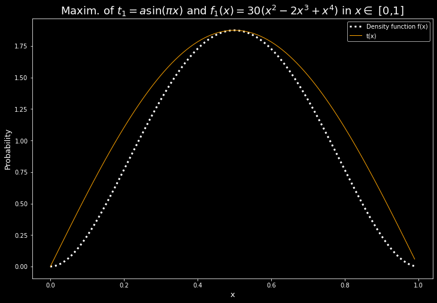

```python
x = np.arange(0,1,0.01)

def f(x):
    try:
        return 30 * (x**2 - 2*x**3 + x**4)
    except:
        return 0

max_f = f (optimize.fmin(lambda x: -f(x), 0, disp = False))
t = lambda x: max_f * np.sin(np.pi*x)

def plot_validation_function (f, t, x, title):
    {""" Display the validation function t(x) ≥ f(x)
    Parameters
    ----------
    f : function
        Density function f(x)
    t : function
        Validation function t(x)
    x : array
        Range of values on x axis
    title : str
        Title of the plt figure
    Returns
    -------
    Plot of the validation function t(x) ≥ f(x)
    """}

    plt.style.use('dark_background')
    plt.rc('grid', linestyle="--", color='gray')
    plt.figure(figsize = (12, 8))
    plt.plot(x, f(x), label = 'Density function f(x)', color='white', linewidth=3, linestyle='dotted')
    plt.plot(x, t(x), label = 't(x)', color='orange', linewidth=1)
    plt.title(title, size = 18)
    plt.ylabel('Probability', size = 13)
    plt.xlabel('x', size = 13)
    plt.legend()
    return plt.show()

plot_validation_function(f, t, x, 'Maxim. of $t_1 = a\sin(\pi x)$ and $f_1(x)=30(x^2-2x^3+x^4)$ in $x \in$ [0,1]')
```

#### **The steps to maximize $f(x)$ over a validation function $t(x)$ are:**

**Step 1:** Pass x to $f(x)$ with a `try/except` statement or `lambda`.anon. function.  
**Step 2:** Minimize function $-f(x)$ **(to max.)** `scipy.optimize.fmin` with any random initial value on $x \in [0,1]$.  
**Step 3:** $max {f(x)}$ = $a$ $t(x)$.  
e.g: $t(x)$ = $a\sin(\pi x)$ = $max {f(x)}[\sin(\pi x)]$.  
**Step 4:** With a `try/except` statement or a `lambda` function we pass x to $t(x)_{max}$.  
**Step 5:** Plot $\bigg(x, f(x) \bigg)$ and $\bigg(x, t(x)_{max} \bigg)$ *(not neccesary)*

#### 2. Maximization of $t(x)$.

Obtain $t(x)$'s maximum value and the value of $x$ at which it occurs in $g(x)$

#### 2. MarcoSC08

$$f(x)=30(x^2-2x^3+x^4)$$

$$t(x)=a \sin(\pi x)$$

$$a=max(f(x))$$

$$c=\int_{0}^{1}a sin(\pi x)dx$$ pulling out

$$c=max(f(x))\int_{0}^{1} sin(\pi x)dx$$ $$c= max(f(x))* [-\frac{cos(\pi y)}{\pi} ]_{0}^{1} = \frac{2}{\pi}max(f (x))$$

$$g(x)=\frac{t(x)}{c}=\frac{max(f(x)) \sin(\pi x)}{\frac{2}{\pi}max(f (x))}=\frac{\pi sin(\pi x)}{2}$$

##### 2. EstebanMqz

##### Maximization of $t(x) = a\sin(\pi x)$

$$c = \int_{0}^{1} t(x)$$

${u = \pi x}$, ${du= \pi dx}$ , ${dx = \frac{du}{\pi}}$

$$c= \int_{0}^{1} a \sin(\pi x) dx$$

$$c=\frac{a}{\pi} \int_{0}^{1} \sin(u) du$$

$$c= \frac{a}{\pi} [-\cos(u)]_{0 }^{1}$$ $c= \frac{a}{\pi} [-\cos(\pi x)]_{0 }^{1}$
$c= \frac{a}{\pi} [-\cos(\pi) + \cos(0)]$
$c= \frac{a}{\pi} [-\cos(\pi) + \ cos(0)]= \frac{2a}{\pi}$

### Inverse Transform Method

3. Use the function found in point 2 and use the inverse transform method seen in class 9, to generate random variables that follow the $g(x)$ distribution.  
   **Note:** Remember that the inverse transform method works with the cumulative probability distribution and not with its density.  
   Again similar to the previous point report all calculations using Markdown (Latex).

#### 3. MarcoSC08

$$G(x)= \int_{0}^{x} g(x)dx = \frac{1}{2} \int_{0}^{x} sin(\pi x)$$

$$G(x)=-\frac{1}{2} [cos(\pi x)]^{x}_{0}= \frac{1}{2} (1-cos(\pi x))$$

$$U= \frac{1}{2} (1-cos(\pi x))$$

Clearing...

$$x=2U=(1-cos(\pi x)$$

$$cos(\pi x)+2U =1 $$

$$cos(\pi x)=1 - 2U $$

$$\pi x= arcos(1 - 2U) $$

$$x= \frac{arcos(1 - 2U)}{\pi } $$

##### 3. EstebanMqz

$F(x) = \int_{0}^{x}f(x)$

Substituting $g(x)$ for $t(x)$ and $c$ for $a$:  
$= \int_{0}^{x}\frac{\pi \sin(\pi x)}{2}$  
Solving the integral:  
$G(x) = -\frac {1}{2}[cos(\pi x)]_{0}^{x} = -\frac{1}{2}cos(\pi x) + \frac{1}{2}$

Having solved the Inverse transform method analitically, we solve for x:
$ G(x) = -\frac{1}{2}cos(\pi x) + \frac{1}{2}= U$ ∴
$ G(x) = -2U + 1 = cos(\pi x) $
Therefore, we can obtain x by solving for cos:
$$ x = \frac{cos^{-1}(-2U +1)}{\pi}$$

$$ x = \frac{cos^{-1}(-2U +1)}{\pi}$$

4. According to point 3, generate 10000 random points that follow the distribution $g(x)$ and compare with its histogram to validate that the generated points follow the desired distribution.

#### 4. MarcoSC08

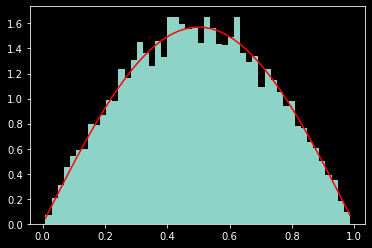

```python
def m_alea(N):
    u =np.random.uniform(0,2/np.pi,N )#full cycle 2pi
    y=list(map(lambda x: (1/np.pi)*np.arccos(1-np.pi*u[x]),range(N)))
    return y

N = 10000
def plot_hist(N):
    r1=m_alea(N)
    y,x,_=plt.hist(r1, bins=50,density=True)
    y2 =(np.pi*np.sin(np.pi*x))/2 #-(1/np.pi)*(np.cos(np.pi*x))+(1/np.pi)
    plt.plot(x,y2,'r-')
    #(1/np.pi)*np.arccos(1-np.pi*u[x]),range(N)))
    plt.show()

plot_hist(N)
```

##### 4. EstebanMqz

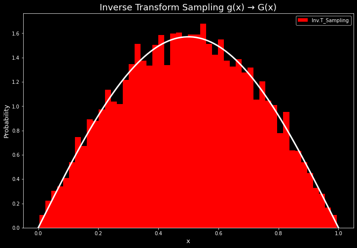

```python
def inverse_transform_sampling(n, G_Inv):
    """
    Generate n samples of a random variable X
    with density function g and cumulative distribution function G.
    Parameters
    ----------
     n: number of samples
    g: density function g
    G_Inv: inverse cumulative distribution function of G
    Returns
    -------
    g_val: array of n samples of X

    """
    u = np.random.rand(n) # random values over u
    g_val = G_Inv(u) # evaluation of inverse transform on u
    return g_val

#pdf(x) and cdf(X)
g = lambda x: (np.pi*np.sin(np.pi*x))/2
G_Inv = lambda u: np.arccos(1 - 2*u) / np.pi

def plot_hist(n, g, title):
    """
    Generate n samples of a random variable X
    with density function g and cumulative distribution function G.
    Parameters
    ----------
     n: number of samples
    g: density function g
    G_Inv: inverse cumulative distribution function of G
    Returns
    -------
    g_val: array of n samples of X
    """
    g_val = inverse_transform_sampling(n, G_Inv)
    x = np.linspace(0, 1, 100)
    g_den = g(x)
    #Histogram aesthetics
    plt.style.use('dark_background')
    plt.rc('grid', linestyle="--", color='gray')
    plt. figure(figsize = (12, 8))
    plt.hist(g_val, bins = 50, density = True, color='r', label='Inv.T_Sampling')
    plt.plot(x, g_den, color="w", linewidth=3)
    plt.title(title, size = 18)
    plt.ylabel('Probability', size= 13)
    plt.xlabel('x', size= 13)
    plt.legend()

    return plt.show()
plot_hist(10000, g, 'Inverse Transform Sampling g(x) → G(x)')
```

In this case, we are generating n random variables that follow the distribution $g(x)$ *(see result 2.)*  
.  
It was obtained by solving for $x$ *(see result 3.)* with the Inverse Transform Method over the cumulative distribution function $G(x)$

#### 5. MarcoSC08

```
The maximum of f is: [1.875]
```

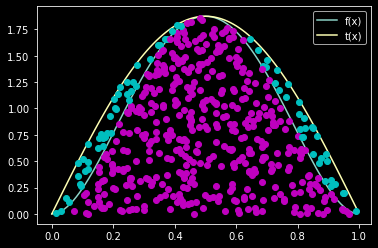

```python
def Accept_reject(R2:'Distributed variables U~U(0,1)',
                 R1:'Variables distributed as g(x)',
                 f:'objective function',
                 t:'major function f'):

    f_x = f(R1)
    t_x = t(R1)
    condition = R2*t_x <=f_x
    [plt.plot(R1[i],R2[i]*t_x[i],'om') if condition[i] else plt.plot(R1[i],R2[i]*t_x[i],' oc')
     for i in range(len(R1))]

    plt.show()

    x = [R1[i] for i in range(len(R1)) if condition[i]]
    return x
# Illustration of the method of accepting and rejecting when t(x) is taken constant

f = lambda x:30*(x**2-2*x**3+x**4)# Objective function
# Maximum of function f
max_f = f(optimize.fmin(lambda x:-f(x),0,disp=False))
# function t
t = lambda x: max_f*np.sin(np.pi*x) # function t in this case is not constant
x = np.arange(0,1,0.01) # Range where the functions will be graphed
print('The maximum of f is:',max_f)

# Graphs of functions
plt.plot(x,f(x),label='f(x)')
plt.plot(x,t(x),label='t(x)')
plt.legend()

# method validation
N = 500 # number of points to simulate
#t(x) constant only need to generate random values U~(0,1)
R2 = np.random.rand(N)
R1 = np.arccos(1-2*np.random.rand(N))/np.pi

x_s=Accept_reject(R2,R1,f,t)
```

##### 5. EstebanMqz

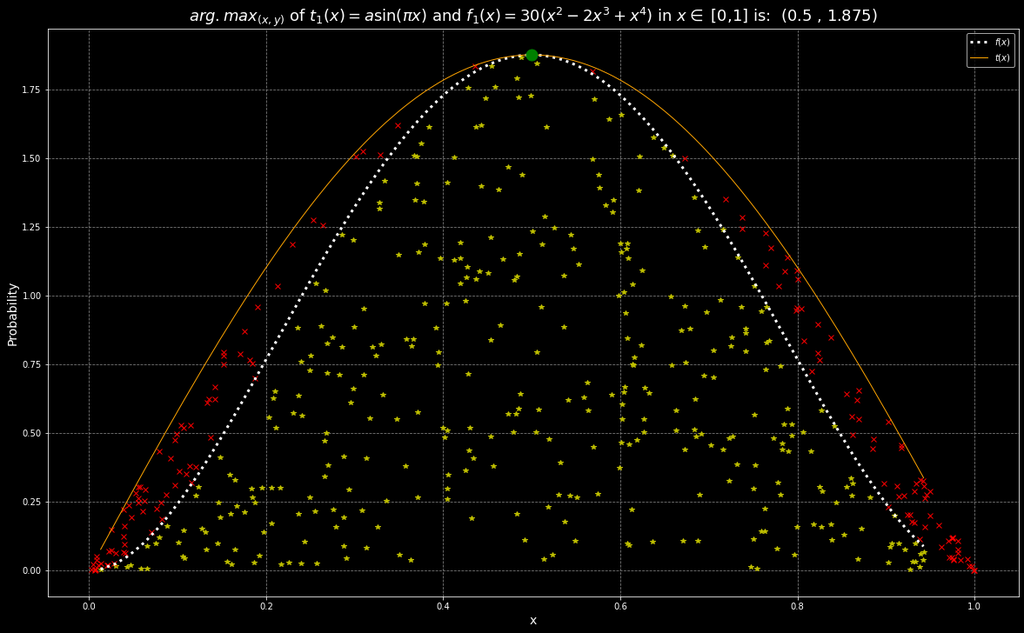

```
The arg. max of f(x) and t(x) is: 0.5 , 1.875) rejected values are 0.29:
```

|  | x | f(x) |
| --- | --- | --- |
| 0 | 0.003 | 0.000 |
| 1 | 0.005 | 0.001 |
| 2 | 0.006 | 0.001 |
| 3 | 0.007 | 0.001 |
| 4 | 0.007 | 0.002 |

```python
#pandas set option to display all dataframe rows
pd.set_option('display.float_format', lambda x: '%.3f' % x)

# # Accept and reject function using list compression
def Accept_rejection(f, t, N, title):
    """ Accept_rejection function creates N random values of R1 and R2 within x domain and the prob. density function f(R1) and the validation function t(R2).
    A logical condition with an operator to be used over R2 and the created values of f(R1), t(R1) is established inside the function *(see condition)*.
    It returns a plot of the accepted and rejected values of f(R1), t(R1), the arg. max (a) of the functions f(x) and t(x) and the rejected values as a tuple (x,y)
    Parameters
    ----------
    R2: Random values over the solution of x over the CDF
    R1: Random values over g(x)
    f: Objective function
    t: Validation function
    N: Number of points to simulate
    condition: Condition to be met
    title: Title of the graph
    Returns
    -------
    scatter plot of the values of R1 and R2 that meet the condition
    a: arg. max of functions f(x) and t(x).
    """
    # Create a list of random numbers between 0 and 1.
    R1 = np.random.rand(N)
    R2 = np.random.rand(N)

    # Evaluate the objective and validation functions at the random points.
    f_x = f(R1)
    t_x = t(R1)
    # R2 Random points satisfying the condition.
    condition = R2*t_x <=f_x

    # Plot the points.
    plt.figure(figsize = (20, 12))
    [plt.plot(R1[i],R2[i]*t_x[i],'*y') if condition[i] else plt.plot(R1[i],R2[i]*t_x[i], 'xr') for i in range(len(R1))]

    # Accepted points.
    x = pd.DataFrame([R1[i] for i in range(len(R1)) if condition[i]]).sort_values(by=0).values
    # Rejected points.
    x_rejected = pd.DataFrame([R1[i] for i in range(len(R1)) if not condition[i]]).sort_values(by=0).values

    # Evaluate objective function.
    f_x = f(x)

    # Get the points rejected by the function f(x).
    f_x_rejected = f(x_rejected)
    x_f_x_rejected = list(zip(x_rejected, f_x_rejected))

    # x,f(x) rejected values as a dataframe
    x_f_x_rejected = pd.DataFrame(x_f_x_rejected, columns=['x', 'f(x)']).sort_values(by='x').values
    x_f_x_rejected = pd.DataFrame(list(zip(*x_f_x_rejected))[0], columns=['x'])
    f_x_rejected = pd.DataFrame(list(zip(*f_x_rejected))[0], columns=['f(x)'])

    rejected_points = pd.concat([x_f_x_rejected, f_x_rejected], axis=1)

    # Maximum of objective function
    a = f(optimize.fmin(lambda x:-f(x), 0, disp=False))
    x_max = optimize.fmin(lambda x:-f(x), 0, disp=False)
    t_max = t(x_max) #Maximize the validation function where f(x) is maximized.



    # Define the validation function

    # Plot the objective function, validation function, and the accepted points
    plt.plot(x,f(x),'m',label='$f(x)$', color='white', linewidth=3 , linestyle='dotted')
    plt.plot(x,t(x),'g',label='$t(x)$', color='orange', linewidth=1)
    plt.plot(x_max, t_max, 'o', color='green', markersize=13) # arg. max

    # Plot Style
    plt.style.use('dark_background')
    plt.grid()
    plt.title(title,fontsize=18)
    plt.xlabel('x',fontsize=14)
    plt.ylabel('Probability',fontsize=14)
    plt.legend(loc = "best")
    plt.show()

    # Return the results
    return print("The arg. max of f(x) and t(x) is: " + str(x_max[0].round(4)) + " , " + str(t_max[0]) + ")" + str(" rejected values are ") + str((len(rejected_points)/N)) + str(":")), rejected_points

N=500
x = np.arange(0,1,0.01)
f = lambda x:30*(x**2-2*x**3+x**4)
N = 500
a = f(optimize.fmin(lambda x: -f(x), 0, disp = False))
x_max = optimize.fmin(lambda x: -f(x), 0, disp = False)
t = lambda x: a * np.sin(np.pi*x)
t_max = t(x_max)


Rejected_values = Accept_rejection(f , t , N,
"$arg. max_{(x,y)}$ of $t_1(x) = a\sin(\pi x)$ and $f_1(x) = 30(x^2-2x^3+x^4)$ in $x \in$ [0,1] is: " +
 " (" + str(x_max[0].round(4)) + " , " + str(t_max[0]) + ")")[1]

Rejected_values.head()
```

6. Compare the percentage of acceptance points when using $t(x)$ constant and $t(x)$ a sinusoidal pulse. Conclude

#### 6. MarcoSC08

```python
def Accept_reject2(R2:'Distributed variables U~U(0,1)', # Accept and reject function using sinusoidal pulse list compression
                 R1:'Variables distributed as g(x)',
                 f:'objective function to generate',
                 t:'function that majors f'):
# R1 = np.random.rand(N)
    f_x = f(R1)
    t_x = t(R1)
    condition = R2*t_x <=f_x
    cont=np.asarray([1 if condition[i] else 0 for i in range(len(R1))]).sum()
    return cont

ans=(Accept_reject2(R2,R1,f,t)/len(R1))*100
"The percentage of acceptance points is:" , ans, "with sine point"
```

```
('The percentage of acceptance points is:', 85.0, 'with sine point')
```

```python
# Accept and reject function using constant t(x) list compression
R2_2=np.random.rand(N)
R1_2=np.random.rand(N)
ans2=(Accept_reject2(R2_2,R1_2,f,t)/len(R1))*100
"The percentage of acceptance points is:" , ans2, "with constant"
```

```
('The percentage of acceptance points is:', 66.8, 'with constant')
```

[output not shown]

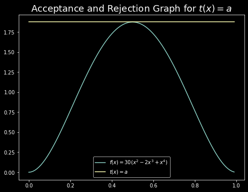

```python
# graph of acceptance and rejection

plt.figure(figsize=[8,6])
plt.title('Acceptance and Rejection Graph for $t(x)=a$',fontsize=18)
plt.plot(x,f(x), label='$f(x)=30(x^2-2x^3+x^4)$')
t = lambda x: a*np.ones([len(x)])
plt.plot(x,t(x),label='$t(x)=a$')
plt.legend(loc="best");


# Simulation of the method
N = 500
R2 = np.random.rand(N)
R1 = np.random.uniform(0,1, size=N)
x_a = Accept_reject2(R2,R1,f,t)
print("The accepted percentage for the sinusoidal function is", (ans2)/N)
print("The accepted percentage for the constant function is", ans/N)
```

##### 6. EstebanMqz

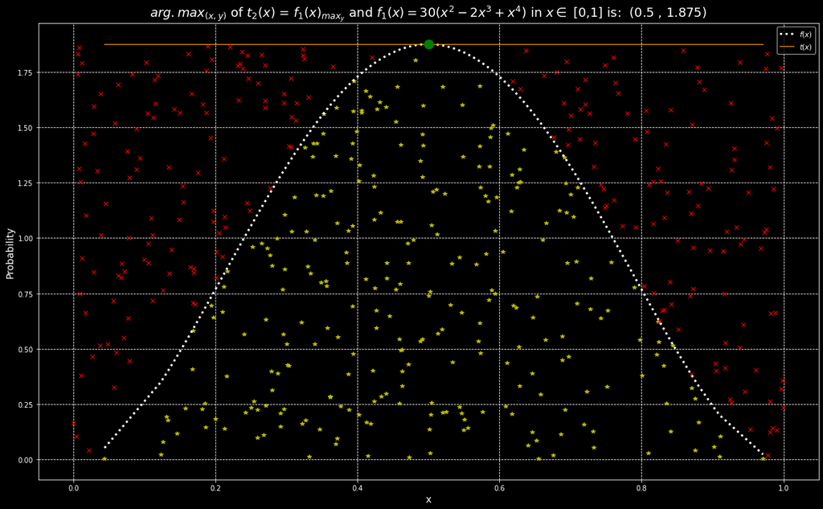

```
The arg. max of f(x) and t(x) is: 0.5 , 1.875) rejected values are 0.458:
```

```python
N = 500
x = np.arange(0,1,0.01)
f = lambda x:30*(x**2-2*x**3+x**4)
R1 = np.random.rand(N)
R2 = np.random.rand(N)
a = f ( optimize . fmin ( lambda x : - f ( x ) , 0 , disp = False ) )
x_max = optimize.fmin(lambda x:-f(x), 0, disp=False)
t = lambda x: a*np.ones([len(x)])
t_max = t(x_max)

Rejected_values = Accept_rejection(f , t , N,
"$arg. max_{(x,y)}$ of $t_2(x)$ = $f_1(x)_{max_{y}}$ and $f_1(x)=30(x^2-2x^3+x^4)$ in $x \in$ [0,1] is: " +
 " (" + str(x_max[0].round(4)) + " , " + str(t_max[0]) + ")")[1]
```

7. Generate a random variable $X$ from the following PDF $$f(x)=20x(1-x)^3$$

#### 7. MarcoSC08

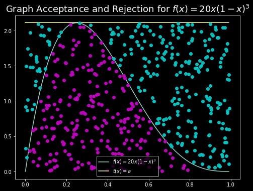

```
The random variable returns the following values: [0.12074975003701549, 0.6025577292360459, 0.29848623946764663, 0.1498304083594696, 0.22883313554834794, 0.5512074831044472, 0.1547340954255173, 0.24188540214039644, 0.2273274335219877, 0.574390789586008]
```

```python
def yes_no(R2:'Distributed variables U~U(0,1)',
                 R1:'Variables distributed as g(x)',
                 f:'objective function',
                 t:'major function f'):

    f_x = f(R1)
    t_x = t(R1)
    condition = R2*t_x <=f_x
    [plt.plot(R1[i],R2[i]*t_x[i],'om') if condition[i] else plt.plot(R1[i],R2[i]*t_x[i],'oc')
     for i in range(len(R1))]

    plt.show()

    x = [R1[i] for i in range(len(R1)) if condition[i]]
    return x

# puntos de aceptacion y rechazo

plt.figure(figsize=[8,6])
plt.title('Graph Acceptance and Rejection for $f(x)=20x(1-x)^3$',fontsize=18)
f = lambda x: 20*x*(1-x)**3
a = f(optimize.fmin(lambda x:-f(x), 0, disp=False))
t = lambda x: a*np.ones([len(x)])


plt.plot(x,f(x), label='$f(x)=20x(1-x)^3$')
plt.plot(x,t(x),label='$t(x)=a$')
plt.legend(loc="best");
# Simulacion del metodo

N = 500
R2 = np.random.rand(N)
R1 = np.random.uniform(0,1, size=N)
V_A = yes_no(R2,R1,f,t)
print(f'The random variable returns the following values: {V_A[:10]}')
```

##### 7. EstebanMqz

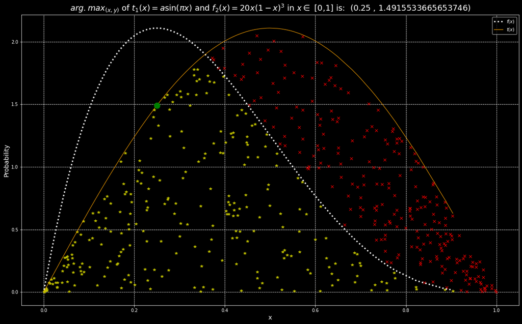

```
The arg. max of f(x) and t(x) is: 0.25 , 1.4915533665653746) rejected values are 0.484:
```

|  | x | f(x) |
| --- | --- | --- |
| 0 | 0.372 | 1.844 |
| 1 | 0.375 | 1.831 |
| 2 | 0.385 | 1.789 |
| 3 | 0.396 | 1.745 |
| 4 | 0.398 | 1.735 |

```python
N = 500 #N valores
x = np.arange(0,1,0.01)
f = lambda x: 20*x*(1-x)**3 #Función objetivo
R1 = np.random.rand(N) #Valores aleatorios
R2 = np.random.rand(N)
a = f(optimize.fmin(lambda x:-f(x), 0, disp=False)) #Valor máx. de f(x)
x_max = optimize.fmin(lambda x:-f(x), 0, disp=False)
t = lambda x: a * np.sin(np.pi*x)
t_max = t(x_max)

Rejected_values = Accept_rejection(f , t , N,
"$arg. max_{(x,y)}$ of $t_1(x) = a\sin(\pi x)$ and $f_2(x)=20x(1-x)^3$ in $x \in$ [0,1] is: "
+ " (" + str(x_max[0].round(4)) + " , " + str(t_max[0]) + ")")[1]
Rejected_values.head()
```

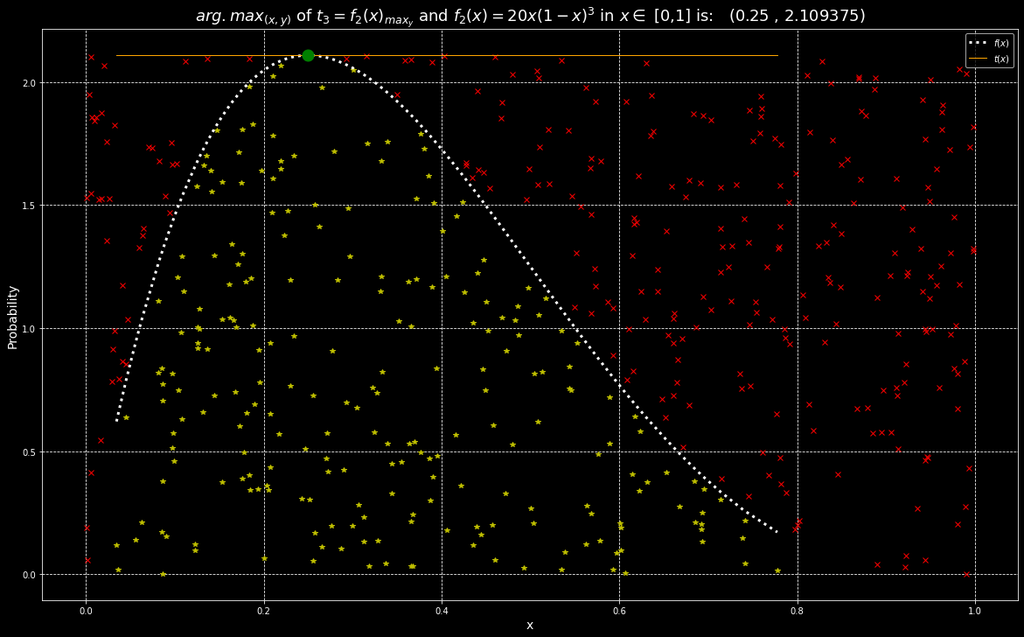

```
The arg. max of f(x) and t(x) is: 0.25 , 2.109375) rejected values are 0.534:
```

|  | x | f(x) |
| --- | --- | --- |
| 0 | 0.001 | 0.016 |
| 1 | 0.001 | 0.027 |
| 2 | 0.002 | 0.042 |
| 3 | 0.004 | 0.079 |
| 4 | 0.006 | 0.111 |

```python
N = 500 #N valores
x = np.arange(0,1,0.01)
f = lambda x: 20*x*(1-x)**3 #Función objetivo
R1 = np.random.rand(N) #Valores aleatorios
R2 = np.random.rand(N)
a = f(optimize.fmin(lambda x:-f(x), 0, disp=False)) #Valor máx. de f(x)
x_max = optimize.fmin(lambda x:-f(x), 0, disp=False)
t = lambda x: a*np.ones([len(x)])
t_max = t(x_max)

Rejected_values = Accept_rejection(f , t , N,
"$arg. max_{(x,y)}$ of $t_3 = f_2(x)_{max_{y}}$ and $f_2(x)=20x(1-x)^3$ in $x \in$ [0,1] is: "
+ "  (" + str(x_max[0].round(4)) + " , " + str(t_max[0]) + ")")[1]

Rejected_values.head()
```